# EC3002C.602-modulo-5-inteligencia-artificial

Repositorio de archivos del **Módulo 5: Inteligencia Artificial de la materia “Economía aplicada y ciencia de datos para el bien público”** impartido en el Tec de Monterrey en el semestre de Otoño-Invierno del 2025.

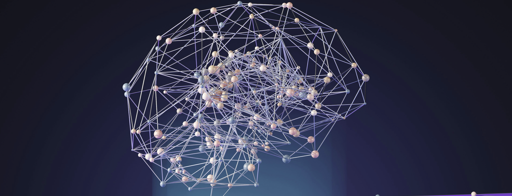

**Profesor:** M.C. Jorge Juvenal Campos Ferreira.

El curso busca que el estudiante:

> Cuente con las herramientas necesarias para el manejo de datos y desarrollo de simulaciones, así como reforzar los conocimientos adquiridos y profundizar en el desarrollo de las competencias mediante la experimentación y la práctica.

Los temas se proponen a partir de efectos prácticos.

## Temario

### 0. Large Language Models

- 0.1 Fundamentos teóricos de LLMs
- 0.2 Utiización de herramientas de LLMs para generación de textos y código

### 5.1 Tráfico vehicular en una ciudad.

- 5.1.1. Repaso de fundamentos de programación
- 5.1.1.1. Definición de objetos, ambientes y funciones.
- 5.1.1.2. Clases y tipos de datos.
- 5.1.1.3. Clases y tipos de estructuras
- 5.1.1.4. Ciclos, flujos y condiciones de paro.

### 5.1.4. Introducción al Lenguaje SQL

- 5.1.5.1. Creación y manipulación de bases de datos
- 5.1.5.2. Ejecución de consultas
- 5.1.5.3. Funciones de ventana
- 5.1.5.4. Concatenación de tablas

### 5.1.6. Aprendizaje de máquina vs Complejidad Social

- 5.1.6.1. Aplicación en Netlogo de tránsito vehicular
- 5.2 Transmisión de un rumor.

### 5.2.1. Repaso de web scraping

- 5.2.1.1. Uso de APIs
- 5.2.1.2. Webscraping y webcrawling

### 5.3 Análisis del crimen y el terrorismo.

- 5.3.1. Sistemas de Información Geográfica
- 5.3.1.1. Proyecciones Cartográficas
- 5.3.1.2. Geometrías y operaciones espaciales

### 5.4 Cambio climático.

- 5.4.1. Introducción a cómputo distribuído con Spark
- 5.4.1.1. Trabajo con clusters
- 5.4.1.2. Aprendizaje de máquina distribuido
- 5.4.1.3. Visualización de datos con cómputo distribuído
- 5.4.2. Modelos de simulación de cambio climático.

### 5.5 Competencia económica.

- 5.5.1. Simulación de Cournot.
- 5.5.2. Simulación de Bertrand
- 5.5.3. Simulación de Guerra de desgaste

## Criterios de evaluación

El 9% de la evaluación correspondiente al módulo 5 se compondrá de lo siguiente:

Se realizará un mínimo de dos examenes, y una serie de tareas relativas a los temas que se revisarán.

## Reto:

**Documento:** Proporcionar información que permita diseñar productos financieros para la población derechohabiente y no derechohabiente del Infonavit (Demanda, Oferta, Grupos de población, Desagregación Territorial.

El reto se desarrollará en equipos de cuatro integrantes.

## Presentaciones

Las presentaciones se encuentran en la carpeta `00_Presentaciones`, de donde se podrán descargar para su uso diario. En una etapa inicial, no todas las presentaciones estarán disponibles para su uso.

Asimísmo, además de estar disponibles en este repositorio de Github, se compartirán por correo electrónico y se subirán a la carpeta de **Canvas** del curso.

- **Al ser un curso con material en desarrollo, los archivos de presentación pueden ir cambiando a lo largo del semestre para complementar algún punto visto en clases posteriores.**
- Presentación 1. Presentación del curso
- Presentación 2. Generación de código con LLMs
- Presentación 3. Introducción a R y RStudio

## Lista de tareas por semana.

**Solo se deja tarea cuando se diga ello explícitamente**. La lista de tareas se encontrará en la carpeta 03_Tareas y ejercicios. Las tareas se enviarán al correo del profesor (juvenal.campos@tec.mx) en la fecha establecida. Las tareas se proporcionarán en formato pdf, y se entregarán en el formato especificado en esta.

## Lista de lecturas, videos y cursos online recomendados.

En esta sección tendremos la lista de lecturas recomendadas del curso. Las lecturas no son obligatorias, pero es recomendable para tener la bibliografía a la mano. Igualmente, dada la naturaleza de la materia y de las herramientas (recientes, poca literatura, literatura que se queda obsoleta pronto), se incluye una lista de cursos recomendados para que, ahora o en un futuro cercano, puedan complementar la formación.

**Clase 1. Presentación.**

- [¿Cómo funcionan los LLMs?](https://www.youtube.com/watch?v=awGfhmsN7Lc)

**Clase 2. Generación de código con LLMS**

- Curso de Claude Code (en inglés, gratis, con registro): https://anthropic.skilljar.com/claude-code-in-action

## Herramientas

A continuación, se enlistan algunas de las herramientas a utilizar durante el curso. Esta lista se ampliará a lo largo del semestre, de ser necesario.

**Programación en R**

- **R:** https://www.r-project.org
- **RStudio:** https://posit.co/download/rstudio-desktop/

**Herramientas de IA:**

- **Claude Code:** https://docs.anthropic.com/en/docs/claude-code/setup
- **Gemini CLI:** https://github.com/google-gemini/gemini-cli
- **Codex CLI:** https://github.com/openai/codex

## Horarios de oficina

A acordar con el profesor a través de correo.